# Pitcher card

# Nate Pearson

RHP · KC

2026 · 42 G (0 GS) · 772 pitches · May 20 – Sep 27, 2026

Independent portfolio sample by Devin Jenkinson, not affiliated with any club. Every number is computed from public Statcast data.

Three big takeaways

1Attack

The 4-seam fastball is the put-away pitch. Use it to finish at-bats.

44% of two-strike pitches · 20% whiffs/swing (50 swings)

It grades 110 Stuff+. No other pitch has 50+ two-strike swings yet.

2Avoid

xRV/100 -0.31 shrunk (raw -0.47) · .300 xwOBAcon · 205 pitches

When behind in the count he throws it 58% of the time.

3Watch

34% chased on 116 out-of-zone pitches

Fastball height splits are too thin to call (95 swings up, 23 down).

Charts

### Movement

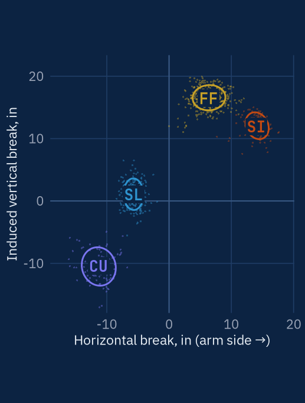

n = 755 pitches. Ellipses hold about 68% of each type; codes sit at the averages.

### Location by count

He throws 50% of pitches in the zone when behind and 40% when ahead.

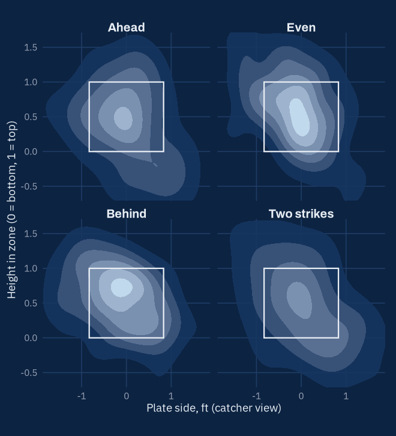

n = 755. Ahead 83 · even 270 · behind 206 · two strikes 196 pitches. Box = rule-book zone.

### Put-away

The FF is 44% of two-strike pitches vs 48% overall.

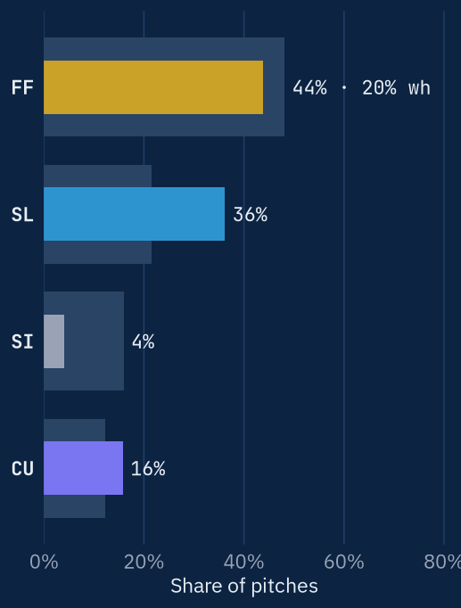

Two-strike n: FF 86, SL 71, CU 31, SI 8. Grey bars = overall usage; wh = whiffs per swing (shown with 50+ swings).

### Arsenal

| Pitch | # | Use | Velo | IVB | HB | VAA | Whiff | Chase | xwOBAcon | xRV/100 | Stuff+ |
| --- | --- | --- | --- | --- | --- | --- | --- | --- | --- | --- | --- |
| 4-Seam (FF) | 205 | 48% | 97.5 | 16.2 | +6.4 | -4.3 | 22% | 19% | .300 | -0.31 | 110 |
| Slider (SL) | 92 | 22% | 89.7 | 1.4 | -5.5 | -7.0 | 22% | 35% | .465 | -0.41 | 110 |
| Sinker (SI) | 68 | 16% | 97.2 | 11.7 | +13.6 | -5.3 | 12% | 31% | .196 | +0.81 | 116 |
| Curveball (CU) | 52 | 12% | 81.7 | -9.5 | -10.9 | -9.4 | 44% | 24% | .240 | +0.39 | 98 |

IVB / HB in inches (HB + = arm side). VAA in degrees at the front of the plate. xRV/100 = expected run value per 100 pitches, pitcher’s view, shrunk with a 250-pitch prior. Stuff+ = this project’s shape-only model (100 = MLB average, 10 = 1 SD).

### Vs. batter hand

| Pitch | LHH # | Use | Whiff | xwOBAcon | RHH # | Use | Whiff | xwOBAcon |
| --- | --- | --- | --- | --- | --- | --- | --- | --- |
| FF | 263 | 58% | 21% | .337 | 82 | 27% | – | .445 |
| SL | 97 | 21% | – | .289 | 120 | 40% | 28% | .405 |
| SI | 22 | 5% | – | .483 | 79 | 26% | – | .231 |
| CU | 72 | 16% | – | .099 | 20 | 7% | – | .027 |

Use = share of pitches to that side. Whiff = whiffs per swing, shown with 50+ swings.